# Deploying Machine Learning using `Sklearn` `Pipelines`

## Kevin Goetsch

### GRUBHUB

# What is this Talk about?

"Pipeline" is an overloaded phrase, every library, every paradigm uses the term.

I am going to talk about a specific technique, in a library, in a language, that you're using for machine learning

- Machine Learning
  - Python
    - scikit-learn
      - `Pipeline`

# Why are you watching this?

- Understand how and when to build `Pipelines`
- Learn how to smooth out your development and deployment of predictive models
- Because you're my father and you still don't know what I do at work

# Road Map

- Sklearn Pipelines
- Modeling Example
- Piece by Piece walkthrough
- Check-in
- Data Science Modeling Lifecycle
  - Development
  - Deployment
- Wrap

# What are Sklearn `Pipelines`?

- `Pipelines` are containers of steps
  - `Transformer`
  - `Estimator`
  - `Pipeline`
  - `FeatureUnion`
- `Pipelines` are used to package a workflow and fit model into a signle object

# Building Blocks of Sklearn Pipelines

### They're like Legos!

## `Estimator`

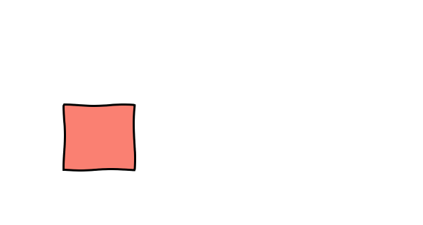

```python
estimator_visual()
```

## `Transformer` & `Estimator`

Note: No communication between the two

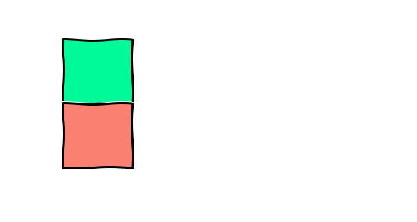

```python
transformer_visual()
```

## `Pipeline` Routes Output of `Transformer` as input into `Estimator`

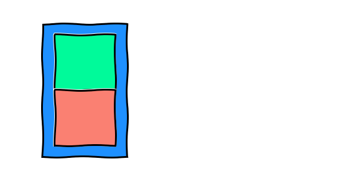

```python
pipeline_visual()
```

## Two side by side `Pipelines`

Note: No communication between the two

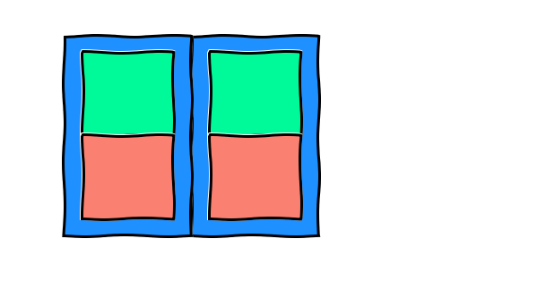

```python
two_pipelines_visual()
```

## `FeatureUnion` joins the results of both `Pipelines` outputs

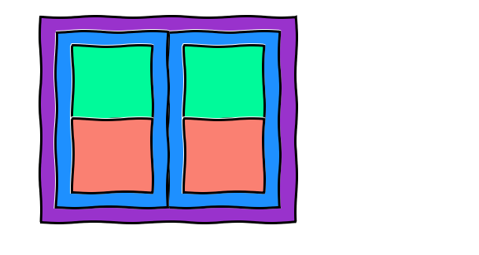

```python
featureUnion_visual()
```

# Modeling Example

Titantic Dataset - predict survival

## Non-Pipeline

```python
response_var = 'Survived'
# TRAIN DATA
train_df = pd.read_csv('data/train.csv', header=0)

# All the ages with no data -> make the median of all Ages
median_age = train_df['Age'].dropna().median()
if len(train_df.Age[ train_df.Age.isnull() ]) > 0:
    train_df.loc[ (train_df.Age.isnull()), 'Age'] = median_age

train_df = train_df.drop(['Pclass',
 'Name',
 'Sex',
 'SibSp',
 'Parch',
 'Ticket',
 'Fare',
 'Cabin',
 'Embarked'], axis=1)
```

```python
# TEST DATA
test_df = pd.read_csv('data/test.csv', header=0)

median_age = test_df['Age'].dropna().median()
if len(test_df.Age[ test_df.Age.isnull() ]) > 0:
    test_df.loc[ (test_df.Age.isnull()), 'Age'] = median_age

test_df = test_df.drop(['Pclass',
 'Name',
 'Sex',
 'SibSp',
 'Parch',
 'Ticket',
 'Fare',
 'Cabin',
 'Embarked'], axis=1)
```

```python
forest = RandomForestClassifier(n_estimators=100,random_state=2065)
forest = forest.fit( train_df[['Age']], train_df[response_var] )

forest_output = forest.predict_proba(test_df[['Age']])
```

## Redone with a Pipeline

```python
response_var = 'Survived'
train_df_pipe = pd.read_csv('data/train.csv', header=0)
test_df_pipe = pd.read_csv('data/test.csv', header=0)

pipeline = make_pipeline(FactorExtractor('Age'),
                         FillNA(train_df_pipe['Age'].dropna().median()),
                         ConvertToDataFrame(),
                         RandomForestClassifier(n_estimators=100, random_state=2065))
```

```python
pipeline.fit(train_df_pipe, train_df_pipe[response_var].values )
pipe_output = pipeline.predict_proba(test_df_pipe)
```

### Pipeline's prediction should match our earlier work

```python
(pipe_output == forest_output).all()
```

```
False
```

## What?

#### earlier...

```
median_age = test_df['Age'].dropna().median()
```

```python
test_df['Age'].dropna().median() == train_df['Age'].dropna().median()
```

```
False
```

```python
test_df['Age'].dropna().median()
```

```
27.0
```

```python
train_df['Age'].dropna().median()
```

```
28.0
```

## Rerun scoring with fixed Median Age

# ...

```python
forest = RandomForestClassifier(n_estimators=100,random_state=2065)
forest = forest.fit( train_df[['Age']], train_df[response_var] )

forest_output = forest.predict_proba(test_df[['Age']])
```

```python
(pipe_output == forest_output).all()
```

```
True
```

This is a common mistake that can be avoided by using pipelines

# Modeling Wrap Up (or why `Pipelines`?)

- Transformations written out once
- Easy to swap out pieces
- Readability ( no more cursing Past Kevin )
- Keeps all intermediate steps together

### But what was really going on in all those steps?

# What's a Transformer?

Python Class that has two main methods

- `transform(X, [y])`
  - Applies transformations on X
- `fit(X, [y])`
  - Applies fit logic on X

```python
class FactorExtractor(TransformerMixin, BaseEstimator):
    def __init__(self, factor):
        self.factor = factor

    def transform(self, data):
        return data[self.factor]

    def fit(self, *_):
        return self
```

Calling `transform` on this Transformer is identical to manually subselecting the target factor.

```python
( FactorExtractor('Age').transform(train_df) == train_df['Age'] ).all()
```

```
True
```

# What's an Estimator

General term for sklearn objects which make predictions.

Methods we'll focus on:

- `fit(X, y)`
  - Fits the model object on the data
- `predict(X)`
  - Predict class labels for samples in X

```python
RandomForestClassifier(n_estimators=100,random_state=2065)
```

```
RandomForestClassifier(bootstrap=True, class_weight=None, criterion='gini',
            max_depth=None, max_features='auto', max_leaf_nodes=None,
            min_samples_leaf=1, min_samples_split=2,
            min_weight_fraction_leaf=0.0, n_estimators=100, n_jobs=1,
            oob_score=False, random_state=2065, verbose=0,
            warm_start=False)
```

# What's a Pipeline?

Pipeline of transforms with a final estimator

- Transform(X, [y])
  - Call `fit` then `transform` on each step contained inside
- Predict(X)
  - Call `transform` on each step then `predict` on the final step

Initialized by passing a list of tuples in the form of

```
(name, transformer)
```

`make_pipeline` just shortcuts the creation process by automatically creating the tuples from a list of transformers

```
make_pipeline(FactorExtractor('Age'),
              FillNA(),
              ConvertToDataFrame(),
              RandomForestClassifier(n_estimators=100, random_state=2065))
```

```
Pipeline([
    ('factorextractor', FactorExtractor('Age')),
    ('fillna', FillNA()),
    ('converttodataframe', ConvertToDataFrame()),
    ('randomforestclassifier', RandomForestClassifier(random_state=2065))
    ]
   )
```

# What's a FeatureUnion?

Basically a horizontal Pipeline

- Transform(X, [y])
  - Call `fit` then `transform` on each step contained inside

Merges the final result of each step into a single output

Initialized by passing a list of tuples in the form of

```
(name, transformer)
```

Caveat: I've written a `DataFrameUnion` class that is identical to `FeatureUnion` except it returns a Pandas dataframe

```python
train_df_pipe[['Age', 'Sex']].head(3)
```

|  | Age | Sex |
| --- | --- | --- |
| 0 | 22.0 | male |
| 1 | 38.0 | female |
| 2 | 26.0 | female |

```python
feature_union = make_dataframeunion([
    make_pipeline(FactorExtractor('Age'),
                  FillNA()),
    make_pipeline(FactorExtractor('Sex'),
                  FillNA('missing'),
                  CategoricalDummifier())
    ])
```

```python
feature_union.fit_transform(train_df_pipe).head(3)
```

|  | Age | Sex[T.male] |
| --- | --- | --- |
| 0 | 22 | 1.0 |
| 1 | 38 | 0.0 |
| 2 | 26 | 0.0 |

# Check-in

### You're all now experts:

- What `pipelines` are
- How to build a basic `pipeline`
- How each piece inside a `pipeline` works

### Next up:

- Data Science Modeling Lifecycle
  - Model Development
  - Model Deployment

# Data Science Modeling Lifecycle

# Model Development

- Feature Engineering
- Model Selection
- Hyperparameter Optimization
- Cross Validation
- Publish

### Can all of this be accomplished without `Pipelines`? Of course it can...

# Why I heart `Pipelines` (Part I)

(emojis are hard in markdown)

Feature Engineering

- Reuse `Transformers`! I use `CategoricalDummifier` in many projects
- Readable transformation logic
- Apply identical transformations to training and test (remember that mistake I made earlier)
- You can put ANYTHING in a `Transformer` wrapper

```python
class xgb_ModelTransformer(TransformerMixin, BaseEstimator):
    def __init__(self, name, model, eval_metric=None):
        self.name = name
        self.model = model
        self.eval_metric = eval_metric

    def fit(self, *args, **kwargs):
        self.model.fit(eval_metric=self.eval_metric, *args, **kwargs)
        return self

    def transform(self, X, **transform_params):
        return pd.DataFrame(self.model.predict(X), columns=[self.name + '_prediction'])
```

Model Selection

- Modularity of `pipelines` makes changes clean and easy
- Tracking the interactions and the hierarch of ensemblage models (models feeding into other models)
- Not tracking intermediate data allows easy model stacking (PCA -> Random Forest)

Hyperparameter Optimization

- `Pipelines` support Gridsearch!

### Gridsearch!

Earlier pipeline we built

```python
pipeline.named_steps.keys()
```

```
['factorextractor', 'fillna', 'converttodataframe', 'randomforestclassifier']
```

```python
params = dict(randomforestclassifier__n_estimators= [100,250,300])
grid_search = GridSearchCV(estimator=pipeline, param_grid=params, verbose=1)
```

```python
grid_search.fit(train_df, train_df[response_var].values)
```

```
Fitting 3 folds for each of 3 candidates, totalling 9 fits
```

```
[Parallel(n_jobs=1)]: Done   9 out of   9 | elapsed:    5.2s finished
```

```
GridSearchCV(cv=None, error_score='raise',
       estimator=Pipeline(steps=[('factorextractor', FactorExtractor(factor='Age')), ('fillna', FillNA(NA_replacement=28.0)), ('converttodataframe', ConvertToDataFrame()), ('randomforestclassifier', RandomForestClassifier(bootstrap=True, class_weight=None, criterion='gini',
            max_depth=None, max_features='auto', ma...n_jobs=1,
            oob_score=False, random_state=2065, verbose=0,
            warm_start=False))]),
       fit_params={}, iid=True, n_jobs=1,
       param_grid={'randomforestclassifier__n_estimators': [100, 250, 300]},
       pre_dispatch='2*n_jobs', refit=True, scoring=None, verbose=1)
```

# Publishing Models

Write our FIT model to disk

Publish to S3, github, a floppy disk, whatever! It's an object that we can do anything with!

```python
joblib.dump(pipeline, './our_fit_pipeline.pkl')
```

[output not shown]

[output cut: 347 more lines]

[output not shown]

# Deployment

### The 3-ish slides you've been waiting 30 minutes for

### The Handoff!

Now that you've got an entire `Pipeline` saved to disk you can pass it anywhere

All your deployed model needs to do is be loaded into memory and have the `predict` method called.

### YOU DO NOT HAVE TO RETRAIN YOUR MODEL EVERY TIME YOU WANT TO SCORE NEW DATA

### (Kevin did you mention this is the most common mistake you see? Because it's super important for you to emphasize if you forgot to)

### Loading from Disk

```python
some_totally_random_model = joblib.load('./our_fit_pipeline.pkl')
some_totally_random_model.named_steps.keys()
```

```
['factorextractor', 'fillna', 'converttodataframe', 'randomforestclassifier']
```

We can even see what parameters went into each step!

```python
some_totally_random_model.steps[1]
```

```
('fillna', FillNA(NA_replacement=28.0))
```

Maybe not a big deal if it's been minutes since we set the replacement to 28.

HUGE deal if it's been 3 months, the coworker who wrote it has quit and the development code is in a jumble.

Just imagine the headache of wading through 20+ transformations done in non-`Pipeline` code.

# Data Engineer != Data Scientist

Passing a standard object will make you many friends

- Engineers don't want to build a bespoke process for every model developed
- A standard deployment approach is easy if every object has the same methods
- Why should an engineer build a seperate process to predict fraud and customer clickthrough rates?
- Data Engineers are specialists too
- If someone's on vacation their coworkers can fill in with little training

Process

- Load model
- Load input data
- model.predict(data)
- write ouput to db

# Why I heart `Pipelines` (Part II)

- Tests can be written
- Models are backed up in version control
  - Rerunning the model version 2.6 that you ran last Dec is a snap
  - Peers can check out and test your model
- Open Source
  - You can write your own `DataFrameUnion` extention
  - You can hire folks already familiar with `Pipelines`
  - You can collaborate across teams, departments, even companies

# Things I hope you walk away with

- What Sklearn `Pipelines` kinda look like
- Where you could benefit from using `Pipelines`
- That I think `Pipelines` are awesome!
- That my Father still has no idea what I do